# Datenauswertung

For the first hypothesis the willingness to buy and to pay for suboptimal vegetables are defined in two variables. Furthermore, Shapiro-Wilk normality tests are conducted to check the normal distribution of the data. The mean and the standard deviation are calculated.

```r
h1K <- as.vector(as.matrix(answers[,c(3,17)]))
h1Z <- as.vector(as.matrix(answers[,c(9,23)]))
shapiro.test(h1K)
```

```
    Shapiro-Wilk normality test

data:  h1K
W = 0.82066, p-value = 6.073e-14
```

```r
shapiro.test(h1Z)
```

```
    Shapiro-Wilk normality test

data:  h1Z
W = 0.88721, p-value = 1.065e-10
```

```r
mean(h1K, na.rm = TRUE)
```

```
[1] -1.053191
```

```r
sd(h1K, na.rm = TRUE)
```

```
[1] 0.9741803
```

```r
mean(h1Z, na.rm = TRUE)
```

```
[1] 2.14984
```

```r
sd(h1Z, na.rm = TRUE)
```

```
[1] 0.7582272
```

As the data isn’t normally distributed, a non-parametric test in form of the Wilcoxon signed rank test has to be conducted.

```r
wilcox.test(h1K, alternative = "less", mu=0)
```

```
    Wilcoxon signed rank test with continuity correction

data:  h1K
V = 937.5, p-value < 2.2e-16
alternative hypothesis: true location is less than 0
```

```r
wilcox.test(h1Z, alternative = "less", mu=2.50)
```

```
    Wilcoxon signed rank test with continuity correction

data:  h1Z
V = 2212.5, p-value = 8.093e-12
alternative hypothesis: true location is less than 2.5
```

**Hypothesis 2**

For the second hypothesis the according variables are combined to a healthiness scale and a Shapiro-Wilk normality test is conducted.

```r
h2 <- as.vector(as.matrix(answers[,c(4,6,8,18,20,22)]))
shapiro.test(h2)
```

```
    Shapiro-Wilk normality test

data:  h2
W = 0.77168, p-value < 2.2e-16
```

```r
mean(h2, na.rm = TRUE)
```

```
[1] 0.03014184
```

```r
sd(h2, na.rm = TRUE)
```

```
[1] 0.6802042
```

As the data isn’t normally distributed, a non-parametric test in form of the Wilcoxon signed rank test has to be conducted again.

```r
wilcox.test(h2, alternative = "less", mu=0)
```

```
    Wilcoxon signed rank test with continuity correction

data:  h2
V = 8780, p-value = 0.838
alternative hypothesis: true location is less than 0
```

**Hypothese 3**

For the third hypotheses, the averages for the perceived healthiness and for the awareness of climate change are calculated.

```r
answers$GemüseAvg <- rowMeans(answers[,c(4,6,8,18,20,22)], na.rm = TRUE)
answers$KlimaAvg <- rowMeans(answers[,c(31:36)],na.rm=TRUE)
```

The two variables are visualized in a scatterplot.

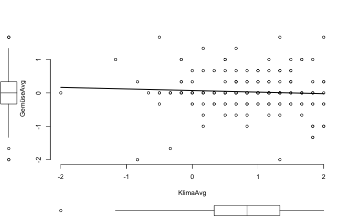

```r
library("car")
scatterplot(GemüseAvg ~ KlimaAvg, data=answers, smooth=FALSE, grid=FALSE, frame=FALSE, col = "black")
```

A linear regression is conducted.

```r
h3.lm <- lm(GemüseAvg ~ KlimaAvg, data = answers)
summary(h3.lm)
```

```
Call:
lm(formula = GemüseAvg ~ KlimaAvg, data = answers)

Residuals:
     Min       1Q   Median       3Q      Max
-2.11086 -0.23778 -0.03136  0.27415  1.69095

Coefficients:
            Estimate Std. Error t value Pr(>|t|)
(Intercept)  0.07111    0.06182   1.150    0.252
KlimaAvg    -0.04770    0.05686  -0.839    0.403

Residual standard error: 0.5569 on 185 degrees of freedom
  (1 observation deleted due to missingness)
Multiple R-squared:  0.00379,   Adjusted R-squared:  -0.001595
F-statistic: 0.7039 on 1 and 185 DF,  p-value: 0.4026
```

On top of the linear regression Kendall’s rank correlation tau and Spearman’s rank correlation rho are calculated.

```r
cor.test(answers$GemüseAvg, answers$KlimaAvg, method="kendall")
```

```
    Kendall's rank correlation tau

data:  answers$GemüseAvg and answers$KlimaAvg
z = -1.0674, p-value = 0.2858
alternative hypothesis: true tau is not equal to 0
sample estimates:
        tau
-0.05967127
```

```r
cor.test(answers$GemüseAvg, answers$KlimaAvg, method="spearman")
```

```
    Spearman's rank correlation rho

data:  answers$GemüseAvg and answers$KlimaAvg
S = 1174476, p-value = 0.2907
alternative hypothesis: true rho is not equal to 0
sample estimates:
        rho
-0.07766273
```

**Hypothesis 4**

As in hypothesis 3, this time the average willingness to buy and pay are calculated.

```r
answers$KaufAvg <- rowMeans(answers[,c(3,17)], na.rm = TRUE)
answers$ZahlAvg <- rowMeans(answers[,c(9,23)],na.rm=TRUE)
```

The variables are visualized in a scatterplot.

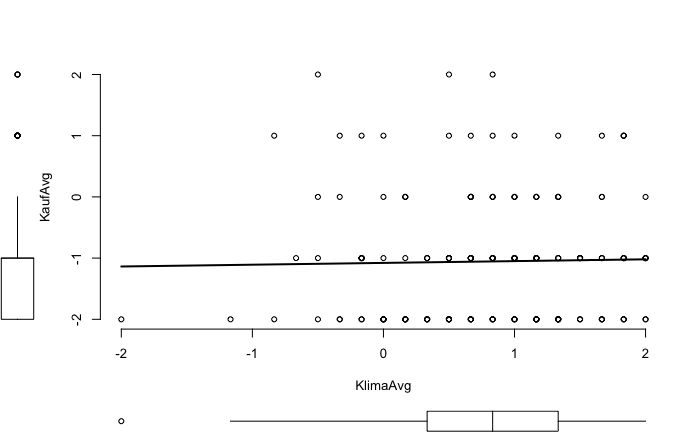

```r
par(mfrow=c(1,2))
scatterplot(KaufAvg ~ KlimaAvg, data=answers, smooth=FALSE, grid=FALSE, frame=FALSE, col = "black")
```

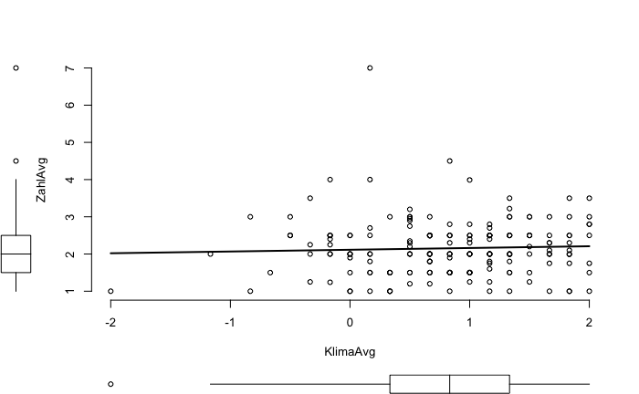

```r
scatterplot(ZahlAvg ~ KlimaAvg, data=answers, smooth=FALSE, grid=FALSE, frame=FALSE, col = "black")
```

A linear regression is conducted. First for the willingness to buy.

```r
h4K.lm <- lm(KaufAvg ~ KlimaAvg, data = answers)
summary(h4K.lm)
```

```
Call:
lm(formula = KaufAvg ~ KlimaAvg, data = answers)

Residuals:
     Min       1Q   Median       3Q      Max
-0.98162 -0.93460  0.03818  0.08272  3.09262

Coefficients:
            Estimate Std. Error t value Pr(>|t|)
(Intercept) -1.07777    0.10871  -9.914   <2e-16 ***
KlimaAvg     0.02969    0.09998   0.297    0.767
---
Signif. codes:  0 ‘***’ 0.001 ‘**’ 0.01 ‘*’ 0.05 ‘.’ 0.1 ‘ ’ 1

Residual standard error: 0.9792 on 185 degrees of freedom
  (1 observation deleted due to missingness)
Multiple R-squared:  0.0004766, Adjusted R-squared:  -0.004926
F-statistic: 0.08821 on 1 and 185 DF,  p-value: 0.7668
```

Afterwards for the willingness to pay.

```r
h4Z.lm <- lm(ZahlAvg ~ KlimaAvg, data = answers)
summary(h4Z.lm)
```

```
Call:
lm(formula = ZahlAvg ~ KlimaAvg, data = answers)

Residuals:
    Min      1Q  Median      3Q     Max
-1.2091 -0.6186 -0.1225  0.3499  4.8775

Coefficients:
            Estimate Std. Error t value Pr(>|t|)
(Intercept)  2.11467    0.08438  25.061   <2e-16 ***
KlimaAvg     0.04723    0.07760   0.609    0.543
---
Signif. codes:  0 ‘***’ 0.001 ‘**’ 0.01 ‘*’ 0.05 ‘.’ 0.1 ‘ ’ 1

Residual standard error: 0.76 on 185 degrees of freedom
  (1 observation deleted due to missingness)
Multiple R-squared:  0.001999,  Adjusted R-squared:  -0.003396
F-statistic: 0.3705 on 1 and 185 DF,  p-value: 0.5435
```

Again, the correlation coefficients are calculated.

```r
cor.test(answers$KaufAvg, answers$KlimaAvg, method="kendall")
```

```
    Kendall's rank correlation tau

data:  answers$KaufAvg and answers$KlimaAvg
z = 0.78147, p-value = 0.4345
alternative hypothesis: true tau is not equal to 0
sample estimates:
       tau
0.04506329
```

```r
cor.test(answers$KaufAvg, answers$KlimaAvg, method="spearman")
```

```
    Spearman's rank correlation rho

data:  answers$KaufAvg and answers$KlimaAvg
S = 1027108, p-value = 0.4339
alternative hypothesis: true rho is not equal to 0
sample estimates:
       rho
0.05755739
```

```r
cor.test(answers$ZahlAvg, answers$KlimaAvg, method="kendall")
```

```
    Kendall's rank correlation tau

data:  answers$ZahlAvg and answers$KlimaAvg
z = 1.1984, p-value = 0.2307
alternative hypothesis: true tau is not equal to 0
sample estimates:
       tau
0.06369692
```

```r
cor.test(answers$ZahlAvg, answers$KlimaAvg, method="spearman")
```

```
    Spearman's rank correlation rho

data:  answers$ZahlAvg and answers$KlimaAvg
S = 998367, p-value = 0.2534
alternative hypothesis: true rho is not equal to 0
sample estimates:
       rho
0.08392946
```

**Hypothese 5**

For hypothesis 5, the willingness to buy and pay have to be separated into vegetarian and vegan consumers on the one side and conventional eaters on the other side.

```r
answers <- answers %>%
  mutate(VegKaufAvg=if_else(Ernährung1_kodiert==2 | Ernährung1_kodiert==3 | Ernährung2_kodiert==2,
                            rowMeans(answers[,c(3,17)], na.rm = TRUE),
                            NA))

answers <- answers %>%
  mutate(VegZahlAvg=if_else(Ernährung1_kodiert==2 | Ernährung1_kodiert==3 | Ernährung2_kodiert==2,
                            rowMeans(answers[,c(9,23)], na.rm = TRUE),
                            NA))
answers <- answers %>%
  mutate(KonvKaufAvg=if_else(Ernährung1_kodiert==1 | Ernährung2_kodiert==1,
                            rowMeans(answers[,c(3,17)], na.rm = TRUE),
                            NA))

answers <- answers %>%
  mutate(KonvZahlAvg=if_else(Ernährung1_kodiert==1 | Ernährung2_kodiert==1,
                            rowMeans(answers[,c(9,23)], na.rm = TRUE),
                            NA))
```

Afterwards, Shapiro-Wilk normality tests as well as means and standard deviations are calculated.

```r
shapiro.test(answers$VegKaufAvg)
```

```
    Shapiro-Wilk normality test

data:  answers$VegKaufAvg
W = 0.83024, p-value = 5.093e-07
```

```r
shapiro.test(answers$KonvKaufAvg)
```

```
    Shapiro-Wilk normality test

data:  answers$KonvKaufAvg
W = 0.78253, p-value = 2.842e-12
```

```r
shapiro.test(answers$VegZahlAvg)
```

```
    Shapiro-Wilk normality test

data:  answers$VegZahlAvg
W = 0.80263, p-value = 9.249e-08
```

```r
shapiro.test(answers$KonvZahlAvg)
```

```
    Shapiro-Wilk normality test

data:  answers$KonvZahlAvg
W = 0.95862, p-value = 0.000779
```

```r
mean(answers$VegKaufAvg, na.rm = TRUE)
```

```
[1] -0.7936508
```

```r
sd(answers$VegKaufAvg, na.rm = TRUE)
```

```
[1] 0.9863378
```

```r
mean(answers$KonvKaufAvg, na.rm = TRUE)
```

```
[1] -1.185484
```

```r
sd(answers$KonvKaufAvg, na.rm = TRUE)
```

```
[1] 0.9488284
```

```r
mean(answers$VegZahlAvg, na.rm = TRUE)
```

```
[1] 2.240635
```

```r
sd(answers$VegZahlAvg, na.rm = TRUE)
```

```
[1] 0.9033359
```

```r
mean(answers$KonvZahlAvg, na.rm = TRUE)
```

```
[1] 2.108952
```

```r
sd(answers$KonvZahlAvg, na.rm = TRUE)
```

```
[1] 0.6733363
```

Wilcoxon rank sum tests have to be conducted.

```r
wilcox.test(answers$VegKaufAvg, answers$KonvKaufAvg, alternative="greater")
```

```
    Wilcoxon rank sum test with continuity correction

data:  answers$VegKaufAvg and answers$KonvKaufAvg
W = 4830.5, p-value = 0.002465
alternative hypothesis: true location shift is greater than 0
```

```r
wilcox.test(answers$VegZahlAvg, answers$KonvZahlAvg, alternative="greater")
```

```
    Wilcoxon rank sum test with continuity correction

data:  answers$VegZahlAvg and answers$KonvZahlAvg
W = 4192, p-value = 0.2051
alternative hypothesis: true location shift is greater than 0
```

**Hypothese 6**

Firstly, we regard the willingness to buy. Shapiro-Wilk normality tests as well as means and standard deviations are calculated.

```r
shapiro.test(answers$Kauf_A1)
```

```
    Shapiro-Wilk normality test

data:  answers$Kauf_A1
W = 0.81052, p-value = 2.873e-09
```

```r
shapiro.test(answers$Kauf_A2)
```

```
    Shapiro-Wilk normality test

data:  answers$Kauf_A2
W = 0.86035, p-value = 1.29e-07
```

```r
mean(answers$Kauf_A1, na.rm = TRUE)
```

```
[1] -1.068182
```

```r
sd(answers$Kauf_A1, na.rm = TRUE)
```

```
[1] 1.014781
```

```r
mean(answers$Kauf_A2, na.rm = TRUE)
```

```
[1] -0.5454545
```

```r
sd(answers$Kauf_A2, na.rm = TRUE)
```

```
[1] 1.320998
```

This time a paired Wilcoxon signed rank test has to be used.

```r
wilcox.test(answers$Kauf_A1, answers$Kauf_A2, paired = TRUE, alternative = "less")
```

```
    Wilcoxon signed rank test with continuity correction

data:  answers$Kauf_A1 and answers$Kauf_A2
V = 182, p-value = 0.000568
alternative hypothesis: true location shift is less than 0
```

For the willingness to pay the variables have to be normalized in order to guarantee the comparability. So the indicated prices from the participants are divided by the reference prices.

```r
answers$Preis_A1_norm <- answers$Preis_A1 / 2.50
answers$Preis_B1_norm <- answers$Preis_B1 / 2.50
answers$Preis_A2_norm <- answers$Preis_A2 / 2.29
answers$Preis_B2_norm <- answers$Preis_B2 / 1.75
```

Shapiro-Wilk normality tests as well as means and standard deviations are calculated.

```r
shapiro.test(answers$Preis_A1_norm)
```

```
    Shapiro-Wilk normality test

data:  answers$Preis_A1_norm
W = 0.81739, p-value = 4.663e-09
```

```r
shapiro.test(answers$Preis_A2_norm)
```

```
    Shapiro-Wilk normality test

data:  answers$Preis_A2_norm
W = 0.96494, p-value = 0.01755
```

```r
mean(answers$Preis_A1_norm, na.rm = TRUE)
```

```
[1] 0.8655455
```

```r
sd(answers$Preis_A1_norm, na.rm = TRUE)
```

```
[1] 0.3392755
```

```r
mean(answers$Preis_A2_norm, na.rm = TRUE)
```

```
[1] 0.9901747
```

```r
sd(answers$Preis_A2_norm, na.rm = TRUE)
```

```
[1] 0.3107891
```

A paired Wilcoxon signed rank test has to be used.

```r
wilcox.test(answers$Preis_A1_norm, answers$Preis_A2_norm, paired = TRUE, alternative = "less")
```

```
    Wilcoxon signed rank test with continuity correction

data:  answers$Preis_A1_norm and answers$Preis_A2_norm
V = 671, p-value = 1.603e-06
alternative hypothesis: true location shift is less than 0
```

**Hypothesis 7**

Hypothesis 7 is tested analogous to Hypothesis 6. Firstly, Shapiro-Wilk normality tests, means and standard deviations are calculated.

```r
shapiro.test(answers$Kauf_B1)
```

```
    Shapiro-Wilk normality test

data:  answers$Kauf_B1
W = 0.82966, p-value = 2.252e-09
```

```r
shapiro.test(answers$Kauf_B2)
```

```
    Shapiro-Wilk normality test

data:  answers$Kauf_B2
W = 0.89618, p-value = 9.39e-07
```

```r
shapiro.test(answers$Preis_B1_norm)
```

```
    Shapiro-Wilk normality test

data:  answers$Preis_B1_norm
W = 0.96359, p-value = 0.007304
```

```r
shapiro.test(answers$Preis_B2_norm)
```

```
    Shapiro-Wilk normality test

data:  answers$Preis_B2_norm
W = 0.84503, p-value = 7.805e-09
```

```r
mean(answers$Kauf_B1, na.rm = TRUE)
```

```
[1] -1.04
```

```r
sd(answers$Kauf_B1, na.rm = TRUE)
```

```
[1] 0.9419516
```

```r
mean(answers$Kauf_B2, na.rm = TRUE)
```

```
[1] 0.06
```

```r
sd(answers$Kauf_B2, na.rm = TRUE)
```

```
[1] 1.261873
```

```r
mean(answers$Preis_B1_norm, na.rm = TRUE)
```

```
[1] 0.855
```

```r
sd(answers$Preis_B1_norm, na.rm = TRUE)
```

```
[1] 0.2693366
```

```r
mean(answers$Preis_B2_norm, na.rm = TRUE)
```

```
[1] 1.017143
```

```r
sd(answers$Preis_B2_norm, na.rm = TRUE)
```

```
[1] 0.3234814
```

Afterwards, paired Wilcoxon signed rank tests are calculated.

```r
wilcox.test(answers$Kauf_B1, answers$Kauf_B2, paired = TRUE, alternative = "less")
```

```
    Wilcoxon signed rank test with continuity correction

data:  answers$Kauf_B1 and answers$Kauf_B2
V = 92.5, p-value = 8.066e-13
alternative hypothesis: true location shift is less than 0
```

```r
wilcox.test(answers$Preis_B1_norm, answers$Preis_B2_norm, paired = TRUE, alternative = "less")
```

```
    Wilcoxon signed rank test with continuity correction

data:  answers$Preis_B1_norm and answers$Preis_B2_norm
V = 994, p-value = 8.087e-05
alternative hypothesis: true location shift is less than 0
```

**Further calculations**

*Discount*

```r
discP <- (2.5 - mean(answers$Preis_A1, na.rm = TRUE)) /2.5
discC <- (2.29 - mean(answers$Preis_A2, na.rm = TRUE)) /2.29
discP2 <- (2.5 - mean(answers$Preis_B1, na.rm = TRUE)) /2.5
discB <- (1.75 - mean(answers$Preis_B2, na.rm = TRUE)) /1.75
mean(c(discP,discC,discP2,discB))
```

```
[1] 0.06803425
```

*Health perceptions with & without label*

```r
healthPre <- as.vector(as.matrix(answers[,c(4,6,8,18,20,22)]))
healthPost <- as.vector(as.matrix(answers[,c(11,13,15,25,27,29)]))

shapiro.test(healthPre)
```

```
    Shapiro-Wilk normality test

data:  healthPre
W = 0.77168, p-value < 2.2e-16
```

```r
shapiro.test(healthPost)
```

```
    Shapiro-Wilk normality test

data:  healthPost
W = 0.8266, p-value < 2.2e-16
```

```r
wilcox.test(healthPre, healthPost, paired = TRUE, alternative = "less")
```

```
    Wilcoxon signed rank test with continuity correction

data:  healthPre and healthPost
V = 7341.5, p-value = 2.175e-08
alternative hypothesis: true location shift is less than 0
```

```r
par(mfrow=c(1,2))
plot(answers$KlimaAvg, answers$Kauf_A1, xlab="awareness of climate change", ylab="willingness to buy",
     main="without label")
abline(lm(Kauf_A1 ~ KlimaAvg, data = answers))
```

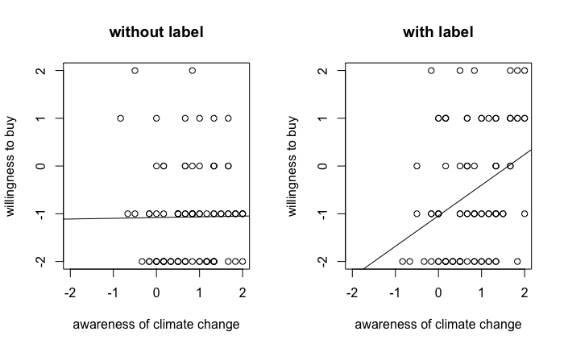

```r
plot(answers$KlimaAvg, answers$Kauf_A2, xlab="awareness of climate change", ylab="willingness to buy",
     main="with label")
abline(lm(Kauf_A2 ~ KlimaAvg, data = answers))
```

*Age*

```r
answers %>%
  group_by(Alter) %>%
  summarize(count=n())
```

| Alter | count |
| --- | --- |
| 18 - 24 Jahre | 67 |
| 25 - 34 Jahre | 74 |
| 35 - 44 Jahre | 7 |
| 45 - 54 Jahre | 11 |
| 55 - 64 Jahre | 19 |
| 65 - 74 | 9 |
| NA | 1 |

```r
NA
```

```r
answers <- answers %>%
  mutate(Alter_code=dplyr::recode(Alter,
  "18 - 24 Jahre" = 1,
  "25 - 34 Jahre" = 2,
  "35 - 44 Jahre" = 3,
  "45 - 54 Jahre" = 4,
  "55 - 64 Jahre" = 5,
  "65 - 74" = 6
))
```

```r
plot(answers$Alter_code, answers$KaufAvg, ylab="Willingness to buy", xlab = "Age", xaxt="n", main="WTB per age group")
axis(1, at=1:6, labels=c("18 - 24","25 - 34","35 - 44","45 - 54","55 - 64","65 - 74"))
```

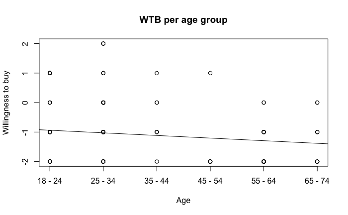

```r
abline(lm(KaufAvg ~ Alter_code, data = answers))
```

```r
plot(answers$Alter_code, answers$GemüseAvg, ylab="Healthiness perceptions", xlab = "Age", xaxt="n", main="Healthiness perceptions per age group")
axis(1, at=1:6, labels=c("18 - 24","25 - 34","35 - 44","45 - 54","55 - 64","65 - 74"))
```

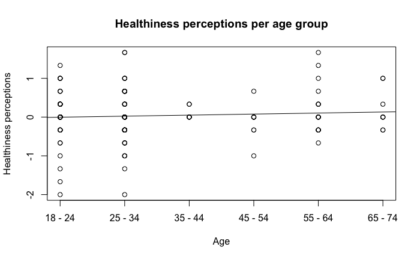

```r
abline(lm(GemüseAvg ~ Alter_code, data = answers))
```

*Gender*

```r
answers %>%
  group_by(Geschlecht) %>%
  summarize(count=n())
```

| Geschlecht | count |
| --- | --- |
| Keine Angabe | 2 |
| Männlich | 68 |
| Weiblich | 117 |
| NA | 1 |

```r
NA
```

```r
answers <- answers %>%
  mutate(Geschlecht_code=dplyr::recode(Geschlecht,
  "Weiblich" = 1,
  "Männlich" = 2
))
```

```r
femaleWTB <- answers[answers$Geschlecht_code == 1,]$KaufAvg
femaleHP <- answers[answers$Geschlecht_code == 1,]$GemüseAvg
femaleCA <- answers[answers$Geschlecht_code == 1,]$KlimaAvg
maleWTB <- answers[answers$Geschlecht_code == 2,]$KaufAvg
maleHP <- answers[answers$Geschlecht_code == 2,]$GemüseAvg
maleCA <- answers[answers$Geschlecht_code == 2,]$KlimaAvg
```

```r
shapiro.test(femaleWTB)
```

```
    Shapiro-Wilk normality test

data:  femaleWTB
W = 0.83187, p-value = 3.199e-10
```

```r
mean(femaleWTB, na.rm = TRUE)
```

```
[1] -0.957265
```

```r
sd(femaleWTB, na.rm = TRUE)
```

```
[1] 1.037181
```

```r
shapiro.test(maleWTB)
```

```
    Shapiro-Wilk normality test

data:  maleWTB
W = 0.79696, p-value = 2.787e-08
```

```r
mean(maleWTB, na.rm = TRUE)
```

```
[1] -1.220588
```

```r
sd(maleWTB, na.rm = TRUE)
```

```
[1] 0.8436875
```

```r
wilcox.test(maleWTB, femaleWTB, alternative = "less")
```

```
    Wilcoxon rank sum test with continuity correction

data:  maleWTB and femaleWTB
W = 3465.5, p-value = 0.06021
alternative hypothesis: true location shift is less than 0
```

```r
shapiro.test(femaleHP)
```

```
    Shapiro-Wilk normality test

data:  femaleHP
W = 0.87568, p-value = 1.846e-08
```

```r
mean(femaleHP, na.rm = TRUE)
```

```
[1] 0.03418803
```

```r
sd(femaleHP, na.rm = TRUE)
```

```
[1] 0.5713207
```

```r
shapiro.test(maleHP)
```

```
    Shapiro-Wilk normality test

data:  maleHP
W = 0.88588, p-value = 1.45e-05
```

```r
mean(maleHP, na.rm = TRUE)
```

```
[1] 0.04411765
```

```r
sd(maleHP, na.rm = TRUE)
```

```
[1] 0.5337822
```

```r
wilcox.test(femaleHP, maleHP, alternative = "less")
```

```
    Wilcoxon rank sum test with continuity correction

data:  femaleHP and maleHP
W = 3828.5, p-value = 0.3258
alternative hypothesis: true location shift is less than 0
```

```r
shapiro.test(femaleCA)
```

```
    Shapiro-Wilk normality test

data:  femaleCA
W = 0.97598, p-value = 0.03385
```

```r
mean(femaleCA, na.rm = TRUE)
```

```
[1] 0.8247863
```

```r
sd(femaleCA, na.rm = TRUE)
```

```
[1] 0.6776559
```

```r
shapiro.test(maleCA)
```

```
    Shapiro-Wilk normality test

data:  maleCA
W = 0.94436, p-value = 0.004374
```

```r
mean(maleCA, na.rm = TRUE)
```

```
[1] 0.8088235
```

```r
sd(maleCA, na.rm = TRUE)
```

```
[1] 0.7913634
```

```r
wilcox.test(maleCA, femaleCA, alternative = "less")
```

```
    Wilcoxon rank sum test with continuity correction

data:  maleCA and femaleCA
W = 4066.5, p-value = 0.6003
alternative hypothesis: true location shift is less than 0
```